# ST661: Assignment 2

#### Question 3

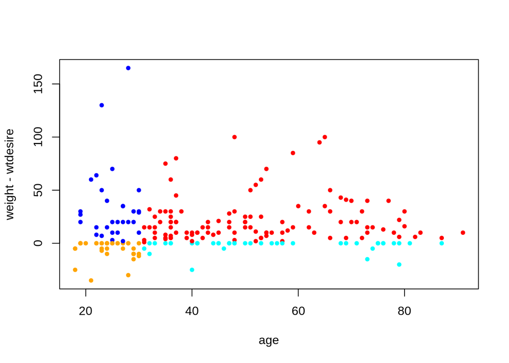

```r
color1 <- ifelse(cdc1$weight > cdc1$wtdesire & cdc1$age > 30,"RED",ifelse(cdc1$weight > cdc1$wtdesire & cdc1$age <= 30 , "BLUE",ifelse(cdc1$weight <= cdc1$wtdesire & cdc1$age <= 30 ,"ORANGE","CYAN")))
plot(weight-wtdesire ~ age , data = cdc1 ,col = color1, pch = 20)
```

b.Recall in a previous lecture we used boxplot.stats to find indices of outliers. Write a function using boxplot.stats called boxplot.out that given a numeric vector returns “low” if there are low outliers, “high” if there are high outliers, “both” if there are high and low outliers, and “none” if there are no outliers.

```r
boxplot.out <- function(sampledata1){
  samreslt1 <- boxplot.stats(sampledata1)
  LQ <- sum(sampledata1 < samreslt1$stats[2] - 1.5*(samreslt1$stats[4]-samreslt1$stats[2]))
  UQ <- sum(sampledata1 > samreslt1$stats[4] + 1.5*(samreslt1$stats[4]-samreslt1$stats[2]))
  ifelse(LQ > 0 & UQ >0 ,return("Both"),ifelse(LQ > 0 , return("Low"),ifelse(UQ > 0,return("High"),return("None"))))
}
```

c.For the cdc1 data, make boxplots showing weight-wtdesire versus genhlth

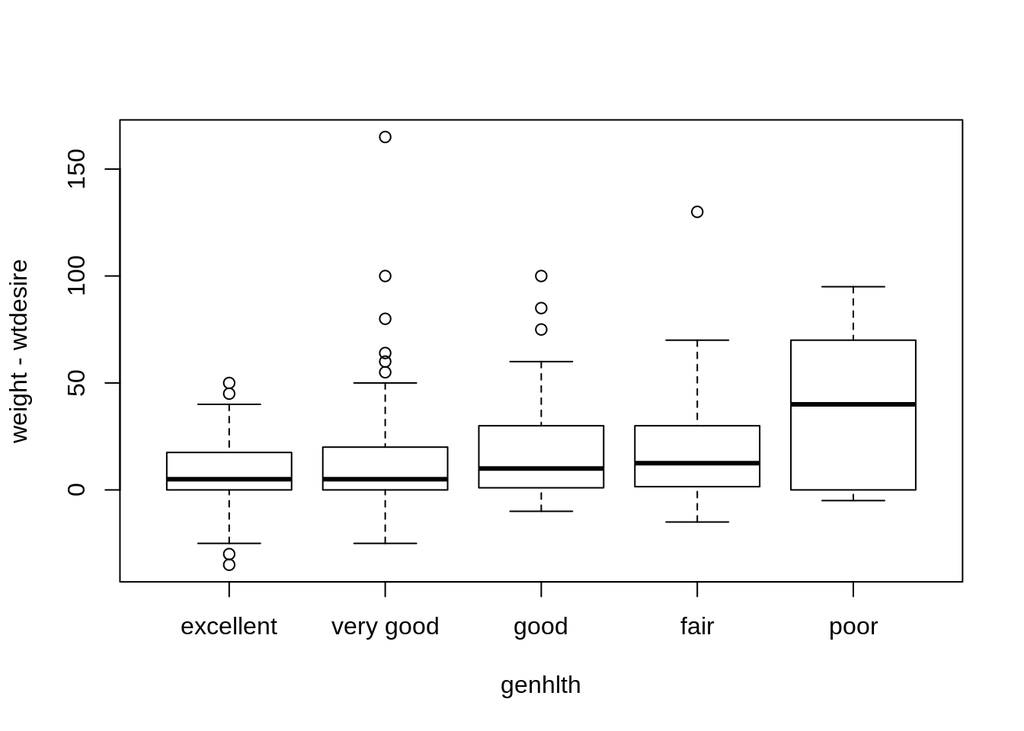

```r
boxplot(weight-wtdesire ~ genhlth , data = cdc1)
```

d.Using boxplot.out and tapply, construct a vector indicating the type of outlier (high, low, both or none) in each boxplot.

```r
tapply(cdc1$weight-cdc1$wtdesire ,  cdc1$genhlth , boxplot.out)
```

```
## excellent very good      good      fair      poor
##    "Both"    "High"    "High"    "High"    "None"
```

5. Construct a color vector that is “red” for boxplots that have high and low outliers, “blue” for just high outliers, “green” for just low outliers, and “yellow” otherwise. Use this vector to colour the boxplots.

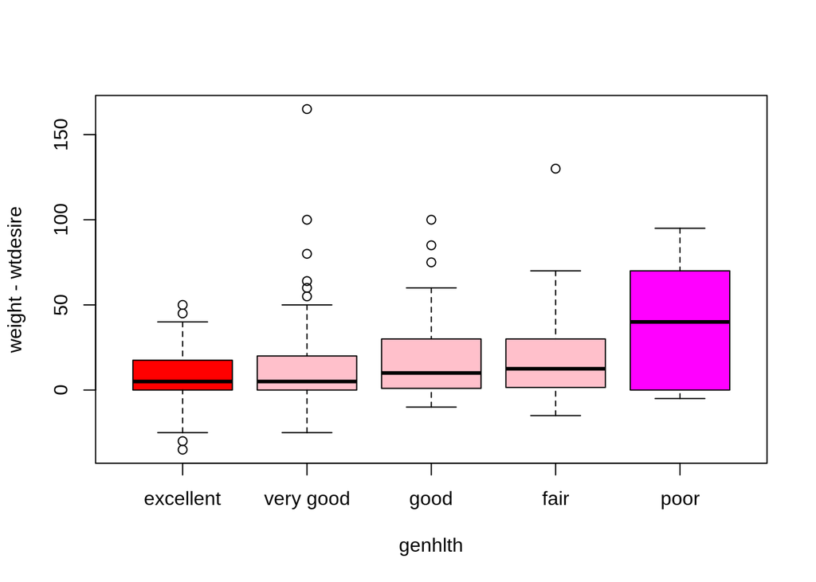

```r
color1 <- ifelse(tapply(cdc1$weight-cdc1$wtdesire , cdc1$genhlth , boxplot.out) == "Both","Red",ifelse(tapply(cdc1$weight-cdc1$wtdesire , cdc1$genhlth , boxplot.out)== "High","pink",ifelse(tapply(cdc1$weight-cdc1$wtdesire , cdc1$genhlth , boxplot.out)=="Low","Green","magenta")))
boxplot(weight-wtdesire ~ genhlth , data = cdc1,col = color1)
```

#### Question 4

Download kobe.csv from Moodle and load it in with load(“kobe.csv”) In the data frame kobe, every row records a shot taken by Kobe Bryant. If he hit the shot (made a basket), a hit, H, is recorded in the column named basket, otherwise a miss, M, is recorded. a.Write a while loop to calculate how many throws are required to reach 3 hoops.

```r
kobe1 <- read.csv("kobe.csv",header = T, stringsAsFactors = F)
str(kobe1)
```

```
## 'data.frame':    133 obs. of  6 variables:
##  $ vs         : chr  "ORL" "ORL" "ORL" "ORL" ...
##  $ game       : int  1 1 1 1 1 1 1 1 1 1 ...
##  $ quarter    : chr  "1" "1" "1" "1" ...
##  $ time       : chr  "9:47" "9:07" "8:11" "7:41" ...
##  $ description: chr  "Kobe Bryant makes 4-foot two point shot" "Kobe Bryant misses jumper" "Kobe Bryant misses 7-foot jumper" "Kobe Bryant makes 16-foot jumper (Derek Fisher assists)" ...
##  $ basket     : chr  "H" "M" "M" "H" ...
```

```r
throws1 = 0
i = 1
while (throws1<3) {
  if(kobe1$basket[i] == "H"){
    throws1 = throws1+1
    NoOfThrows1 <- i
    i = i+1

  }else {
    i = i+1
  }

}
print("Number  Throws Required:-")
```

```
## [1] "Number  Throws Required:-"
```

```r
NoOfThrows1
```

```
## [1] 5
```

b.Write another while loop to calculate how many throws are required to reach 3 more hoops hoops

```r
throws12 = 0
i1 = 1
while (throws12<6) {
  if(kobe1$basket[i1] == "H"){
    throws12 = throws12+1
    NoOfThrows12 <- i1
    i1 = i1+1

  }else {
    i1 = i1+1
  }

}
NoOfSecond3Throws = NoOfThrows12 - NoOfThrows1
NoOfSecond3Throws
```

```
## [1] 7
```